# Machine Learning Assignment 2

# Problem 1: Applying k-Nearest Neighbors to predict the success of a marketing campaign. For this assignment, we will be using the bank marketing dataset from UCI. The data has 17 attributes and is related to marketing campaigns (phone calls) of a Portuguese banking institution. The classification goal is to predict if the client will subscribe a term deposit (variable y).

# Please download and unzip the dataset from here: https://archive.ics.uci.edu/dataset/222/bank+marketing .The dataset you will be working on is stored in bank-full.csv.

# Open the file bank-names.txt and carefully read the attribute information to understand what information is stored in each attribute, what values each attribute can take and so on.

# 1.(1pt) Download the dataset and store it in a dataframe in R. Note: the attributes are separated by semicolon so make sure you set “sep” option correctly inside read.csv

```r
# Let's read the data from the data set
bank = read.csv("/Users/nancy/Downloads/bank+marketing/bank/bank-full.csv", sep = ';', na.strings = "unknown")
bank
```

| age | job | marital | education | default | balance | housing | loan | contact | day | month | duration | campaign | pdays | previous | poutcome | y |
| --- | --- | --- | --- | --- | --- | --- | --- | --- | --- | --- | --- | --- | --- | --- | --- | --- |
| 58 | management | married | tertiary | no | 2143 | yes | no | NA | 5 | may | 261 | 1 | -1 | 0 | NA | no |
| 44 | technician | single | secondary | no | 29 | yes | no | NA | 5 | may | 151 | 1 | -1 | 0 | NA | no |
| 33 | entrepreneur | married | secondary | no | 2 | yes | yes | NA | 5 | may | 76 | 1 | -1 | 0 | NA | no |
| 47 | blue-collar | married | NA | no | 1506 | yes | no | NA | 5 | may | 92 | 1 | -1 | 0 | NA | no |
| 33 | NA | single | NA | no | 1 | no | no | NA | 5 | may | 198 | 1 | -1 | 0 | NA | no |
| 35 | management | married | tertiary | no | 231 | yes | no | NA | 5 | may | 139 | 1 | -1 | 0 | NA | no |
| 28 | management | single | tertiary | no | 447 | yes | yes | NA | 5 | may | 217 | 1 | -1 | 0 | NA | no |
| 42 | entrepreneur | divorced | tertiary | yes | 2 | yes | no | NA | 5 | may | 380 | 1 | -1 | 0 | NA | no |
| 58 | retired | married | primary | no | 121 | yes | no | NA | 5 | may | 50 | 1 | -1 | 0 | NA | no |
| 43 | technician | single | secondary | no | 593 | yes | no | NA | 5 | may | 55 | 1 | -1 | 0 | NA | no |

[output cut: 990 more lines]

# Some Information of the variables from the dataset:

# Input variables:

#bank client data: 1 - age (numeric) 2 - job : type of job (categorical:  
“admin.”,“unknown”,“unemployed”,“management”,“housemaid”,“entrepreneur”,“student”,“blue-collar”,“self-employed”, “retired”,“technician”,“services”) 3 - marital : marital status (categorical: “married”,“divorced”,“single”; note: “divorced” means divorced or widowed) 4 - education (categorical: “unknown”,“secondary”,“primary”,“tertiary”) 5 - default: has credit in default? (binary: “yes”,“no”) 6 - balance: average yearly balance, in euros (numeric) 7 - housing: has housing loan? (binary: “yes”,“no”) 8 - loan: has personal loan? (binary: “yes”,“no”) # related with the last contact of the current campaign: 9 - contact: contact communication type (categorical: “unknown”,“telephone”,“cellular”) 10 - day: last contact day of the month (numeric) 11 - month: last contact month of year (categorical: “jan”, “feb”, “mar”, …, “nov”, “dec”) 12 - duration: last contact duration, in seconds (numeric) # other attributes: 13 - campaign: number of contacts performed during this campaign and for this client (numeric, includes last contact) 14 - pdays: number of days that passed by after the client was last contacted from a previous campaign (numeric, -1 means client was not previously contacted) 15 - previous: number of contacts performed before this campaign and for this client (numeric) 16 - poutcome: outcome of the previous marketing campaign (categorical: “unknown”,“other”,“failure”,“success”)

Output variable (desired target): 17 - y - has the client subscribed a term deposit? (binary: “yes”,“no”)

2. (2 pt) Explore the overall structure of the dataset using the str() function. Get a summary statistics of each variable. Explain what is the type of each variable ( categorical( unordered), categorical (ordered), or continuous)

```r
# Exploring the overall structure of the attributes
str(bank)
```

```
'data.frame':   45211 obs. of  17 variables:
 $ age      : int  58 44 33 47 33 35 28 42 58 43 ...
 $ job      : chr  "management" "technician" "entrepreneur" "blue-collar" ...
 $ marital  : chr  "married" "single" "married" "married" ...
 $ education: chr  "tertiary" "secondary" "secondary" NA ...
 $ default  : chr  "no" "no" "no" "no" ...
 $ balance  : int  2143 29 2 1506 1 231 447 2 121 593 ...
 $ housing  : chr  "yes" "yes" "yes" "yes" ...
 $ loan     : chr  "no" "no" "yes" "no" ...
 $ contact  : chr  NA NA NA NA ...
 $ day      : int  5 5 5 5 5 5 5 5 5 5 ...
 $ month    : chr  "may" "may" "may" "may" ...
 $ duration : int  261 151 76 92 198 139 217 380 50 55 ...
 $ campaign : int  1 1 1 1 1 1 1 1 1 1 ...
 $ pdays    : int  -1 -1 -1 -1 -1 -1 -1 -1 -1 -1 ...
 $ previous : int  0 0 0 0 0 0 0 0 0 0 ...
 $ poutcome : chr  NA NA NA NA ...
 $ y        : chr  "no" "no" "no" "no" ...
```

According to this, We can analyse that, We have around 45211 observations and 16 columns/variables and 1 target variable: “y”.

```r
summary(bank)
```

```
      age            job              marital           education           default             balance         housing
 Min.   :18.00   Length:45211       Length:45211       Length:45211       Length:45211       Min.   : -8019   Length:45211
 1st Qu.:33.00   Class :character   Class :character   Class :character   Class :character   1st Qu.:    72   Class :character
 Median :39.00   Mode  :character   Mode  :character   Mode  :character   Mode  :character   Median :   448   Mode  :character
 Mean   :40.94                                                                               Mean   :  1362
 3rd Qu.:48.00                                                                               3rd Qu.:  1428
 Max.   :95.00                                                                               Max.   :102127
     loan             contact               day           month              duration         campaign          pdays
 Length:45211       Length:45211       Min.   : 1.00   Length:45211       Min.   :   0.0   Min.   : 1.000   Min.   : -1.0
 Class :character   Class :character   1st Qu.: 8.00   Class :character   1st Qu.: 103.0   1st Qu.: 1.000   1st Qu.: -1.0
 Mode  :character   Mode  :character   Median :16.00   Mode  :character   Median : 180.0   Median : 2.000   Median : -1.0
                                       Mean   :15.81                      Mean   : 258.2   Mean   : 2.764   Mean   : 40.2
                                       3rd Qu.:21.00                      3rd Qu.: 319.0   3rd Qu.: 3.000   3rd Qu.: -1.0
                                       Max.   :31.00                      Max.   :4918.0   Max.   :63.000   Max.   :871.0
    previous          poutcome              y
 Min.   :  0.0000   Length:45211       Length:45211
 1st Qu.:  0.0000   Class :character   Class :character
 Median :  0.0000   Mode  :character   Mode  :character
 Mean   :  0.5803
 3rd Qu.:  0.0000
 Max.   :275.0000
```

The categorical variables are: job, marital, education, default, housing, loan, contact, month, poutcome ordered: education [ As this have levels of education making it a rankable category] unordered: job, marital, default, housing, loan, contact, month, poutcome The target variable: y is also a categorical variable The numerical variables: age, balance, day, duration, campaign, pdays, previous Discrete: age, day, campaign, pdays, previous Continuous: balance, duration

3. (1pt) Get the frequency table of the target variable “y” to see how many observations you have in each category of y. Is y balanced? that is, do you have roughly same observations in y=yes and y=no?

```r
# First of all let's create a new dataframe to store the data.
# To my understanding, it's a great practice to make any new changes in the copied version of data and not the original.
bank_copy = bank
print(bank_copy)
```

| age | job | marital | education | default | balance | housing | loan | contact | day | month | duration | campaign | pdays | previous | poutcome | y |
| --- | --- | --- | --- | --- | --- | --- | --- | --- | --- | --- | --- | --- | --- | --- | --- | --- |
| 58 | management | married | tertiary | no | 2143 | yes | no | NA | 5 | may | 261 | 1 | -1 | 0 | NA | no |
| 44 | technician | single | secondary | no | 29 | yes | no | NA | 5 | may | 151 | 1 | -1 | 0 | NA | no |
| 33 | entrepreneur | married | secondary | no | 2 | yes | yes | NA | 5 | may | 76 | 1 | -1 | 0 | NA | no |
| 47 | blue-collar | married | NA | no | 1506 | yes | no | NA | 5 | may | 92 | 1 | -1 | 0 | NA | no |
| 33 | NA | single | NA | no | 1 | no | no | NA | 5 | may | 198 | 1 | -1 | 0 | NA | no |
| 35 | management | married | tertiary | no | 231 | yes | no | NA | 5 | may | 139 | 1 | -1 | 0 | NA | no |
| 28 | management | single | tertiary | no | 447 | yes | yes | NA | 5 | may | 217 | 1 | -1 | 0 | NA | no |
| 42 | entrepreneur | divorced | tertiary | yes | 2 | yes | no | NA | 5 | may | 380 | 1 | -1 | 0 | NA | no |
| 58 | retired | married | primary | no | 121 | yes | no | NA | 5 | may | 50 | 1 | -1 | 0 | NA | no |
| 43 | technician | single | secondary | no | 593 | yes | no | NA | 5 | may | 55 | 1 | -1 | 0 | NA | no |

[output cut: 990 more lines]

```r
frequency_table <- table(bank_copy$y)
print(frequency_table)
```

```
   no   yes
39922  5289
```

As per this, y is imbalanced having different number of observations.

4. (3 pts) Explore the data in order to investigate the association between the target variable y and other variables in the dataset. Which of the other variables are associated with y? Use appropriate plots and statistic tests to answer this question.

So, we know that: Our target variable - y is categorical and binary For our independent variables, we have two types For categorical -> we’ll use chi-square and mosaic plot For numerical -> we’ll use t-test and box plots

```r
# Let's do first for categorical:
# job, marital, education, default, housing, loan, contact, month, poutcome
chi_sq_job <- chisq.test(bank_copy$job, bank_copy$y)
print(chi_sq_job)
```

```
    Pearson's Chi-squared test

data:  bank_copy$job and bank_copy$y
X-squared = 836.14, df = 10, p-value < 2.2e-16
```

```r
chi_sq_marital <- chisq.test(bank_copy$marital, bank_copy$y)
print(chi_sq_marital)
```

```
    Pearson's Chi-squared test

data:  bank_copy$marital and bank_copy$y
X-squared = 196.5, df = 2, p-value < 2.2e-16
```

```r
chi_sq_education <- chisq.test(bank_copy$education, bank_copy$y)
print(chi_sq_education)
```

```
    Pearson's Chi-squared test

data:  bank_copy$education and bank_copy$y
X-squared = 233.75, df = 2, p-value < 2.2e-16
```

```r
chi_sq_default <- chisq.test(bank_copy$default, bank_copy$y)
print(chi_sq_default)
```

```
    Pearson's Chi-squared test with Yates' continuity correction

data:  bank_copy$default and bank_copy$y
X-squared = 22.202, df = 1, p-value = 2.454e-06
```

```r
chi_sq_housing <- chisq.test(bank_copy$housing, bank_copy$y)
print(chi_sq_housing)
```

```
    Pearson's Chi-squared test with Yates' continuity correction

data:  bank_copy$housing and bank_copy$y
X-squared = 874.82, df = 1, p-value < 2.2e-16
```

```r
chi_sq_loan <- chisq.test(bank_copy$loan, bank_copy$y)
print(chi_sq_loan)
```

```
    Pearson's Chi-squared test with Yates' continuity correction

data:  bank_copy$loan and bank_copy$y
X-squared = 209.62, df = 1, p-value < 2.2e-16
```

```r
chi_sq_contact <- chisq.test(bank_copy$contact, bank_copy$y)
print(chi_sq_contact)
```

```
    Pearson's Chi-squared test with Yates' continuity correction

data:  bank_copy$contact and bank_copy$y
X-squared = 4.5932, df = 1, p-value = 0.0321
```

```r
chi_sq_month <- chisq.test(bank_copy$month, bank_copy$y)
print(chi_sq_month)
```

```
    Pearson's Chi-squared test

data:  bank_copy$month and bank_copy$y
X-squared = 3061.8, df = 11, p-value < 2.2e-16
```

```r
chi_sq_poutcome <- chisq.test(bank_copy$poutcome, bank_copy$y)
print(chi_sq_poutcome)
```

```
    Pearson's Chi-squared test

data:  bank_copy$poutcome and bank_copy$y
X-squared = 1822.2, df = 2, p-value < 2.2e-16
```

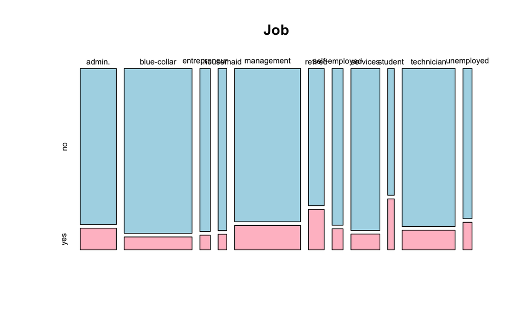

```r
#job, marital, education, default, housing, loan, contact, month, poutcome
mosaicplot(table(bank_copy$job, bank_copy$y), main = "Job", color = c("lightblue", "pink"))
```

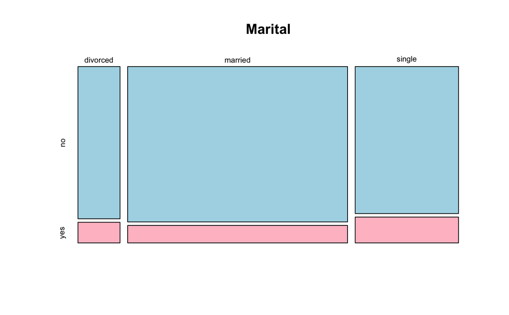

```r
mosaicplot(table(bank_copy$marital, bank_copy$y), main = "Marital", color = c("lightblue","pink"))
```

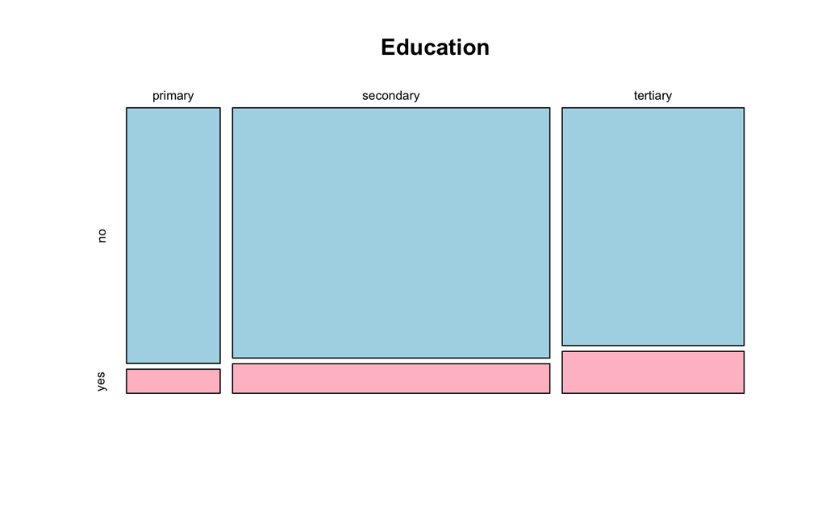

```r
mosaicplot(table(bank_copy$education, bank_copy$y), main = "Education", color = c("lightblue", "pink"))
```

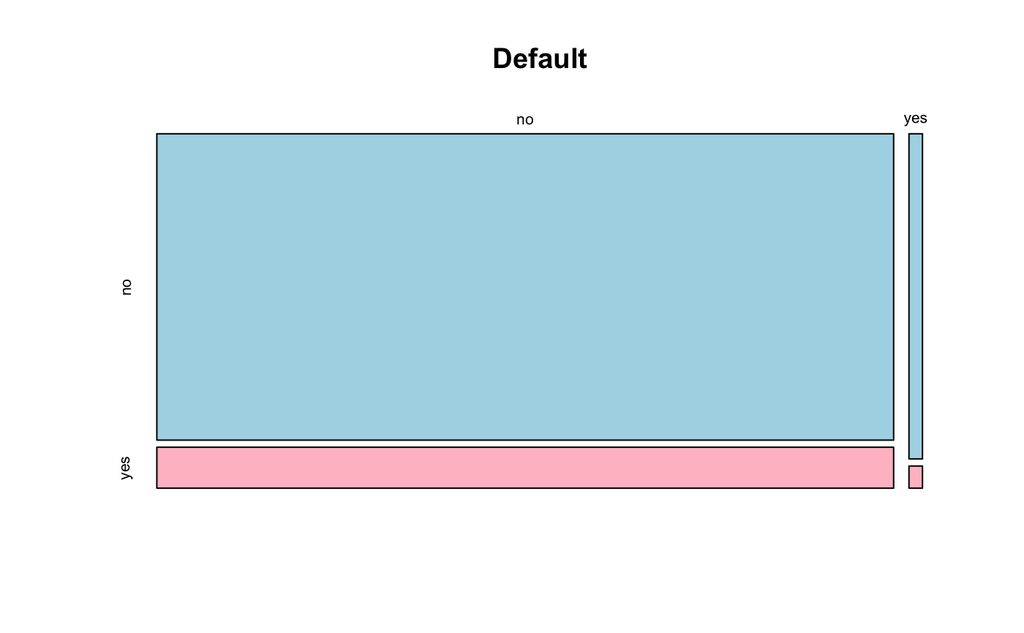

```r
mosaicplot(table(bank_copy$default, bank_copy$y), main = "Default", color = c("lightblue", "pink"))
```

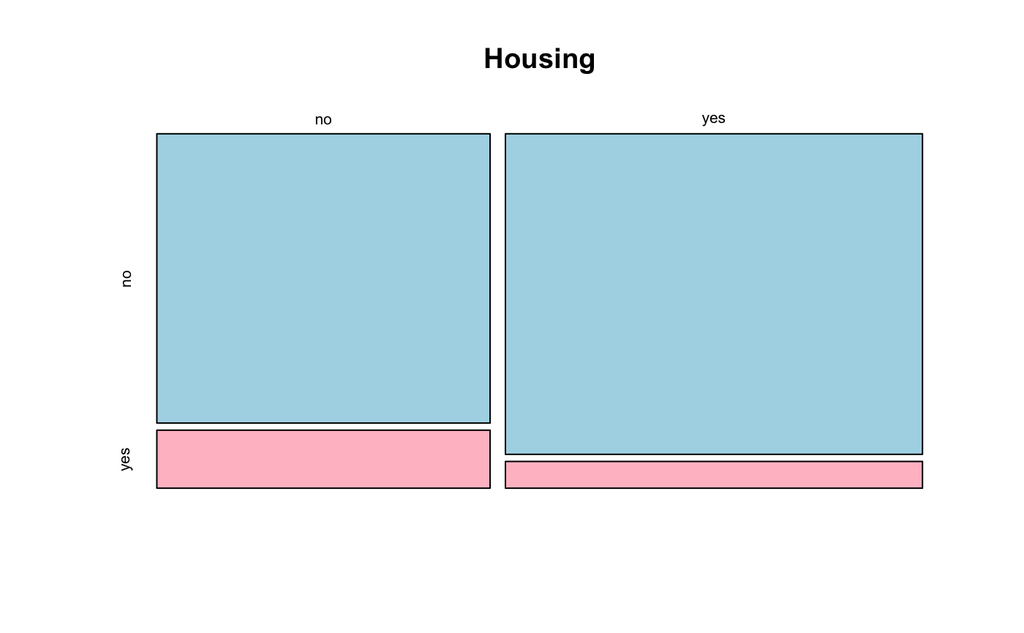

```r
mosaicplot(table(bank_copy$housing, bank_copy$y), main = "Housing", color = c("lightblue", "pink"))
```

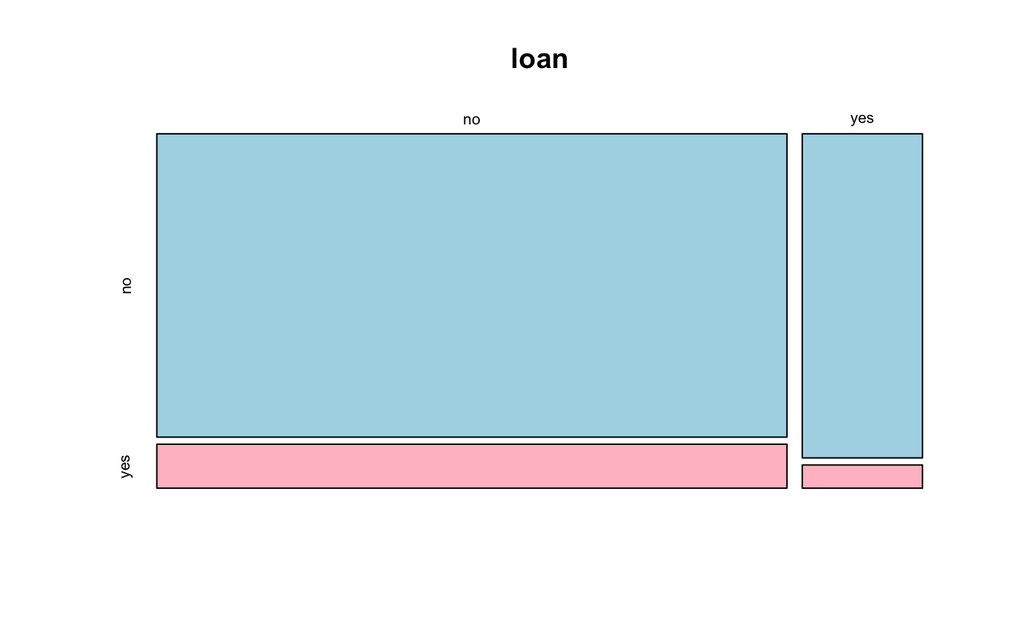

```r
mosaicplot(table(bank_copy$loan, bank_copy$y), main = "loan", color = c("lightblue", "pink"))
```

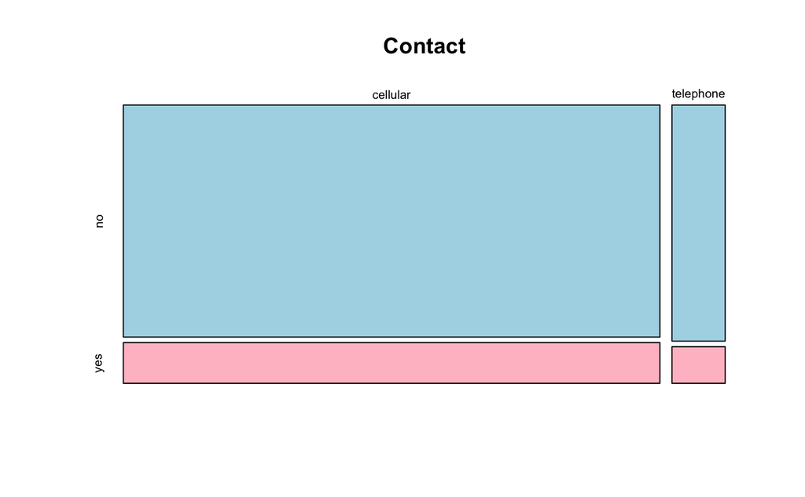

```r
mosaicplot(table(bank_copy$contact, bank_copy$y), main = "Contact", color = c("lightblue", "pink"))
```

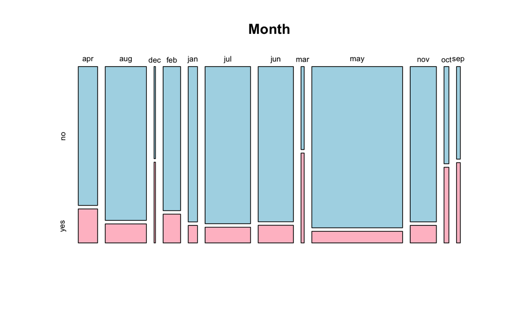

```r
mosaicplot(table(bank_copy$month, bank_copy$y), main = "Month", color = c("lightblue", "pink"))
```

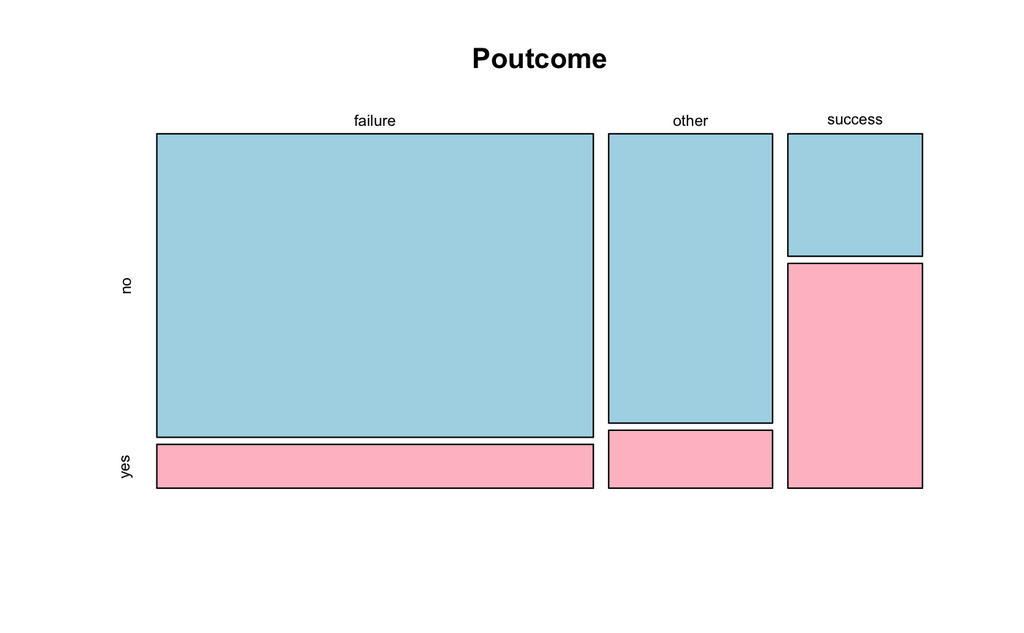

```r
mosaicplot(table(bank_copy$poutcome, bank_copy$y), main = "Poutcome", color = c("lightblue", "pink"))
```

So, Assuming p-value = 0.05, All the categorical variables above have it’s p-value less than the threshold value ie. 0.05. So, we’ll reject null hypothesis saying that these variables are associated with the target variable.

```r
# Now Let's do for numerical:
# age, balance, day, duration, campaign, pdays, previous

kruskal_test_age <- kruskal.test(age ~ y, data = bank_copy)
print(kruskal_test_age)
```

```
    Kruskal-Wallis rank sum test

data:  age by y
Kruskal-Wallis chi-squared = 3.4614, df = 1, p-value = 0.06282
```

```r
t_test_balance <- t.test(balance ~ y, data = bank_copy)
print(t_test_balance)
```

```
    Welch Two Sample t-test

data:  balance by y
t = -9.9335, df = 6339.8, p-value < 2.2e-16
alternative hypothesis: true difference in means between group no and group yes is not equal to 0
95 percent confidence interval:
 -599.3347 -401.7712
sample estimates:
 mean in group no mean in group yes
         1303.715          1804.268
```

```r
t_test_day <- t.test(day ~ y, data = bank_copy)
print(t_test_day)
```

```
    Welch Two Sample t-test

data:  day by y
t = 5.917, df = 6691.7, p-value = 3.441e-09
alternative hypothesis: true difference in means between group no and group yes is not equal to 0
95 percent confidence interval:
 0.4908478 0.9772262
sample estimates:
 mean in group no mean in group yes
         15.89229          15.15825
```

```r
t_test_duration <- t.test(duration ~ y, data = bank_copy)
print(t_test_duration)
```

```
    Welch Two Sample t-test

data:  duration by y
t = -57.514, df = 5685.3, p-value < 2.2e-16
alternative hypothesis: true difference in means between group no and group yes is not equal to 0
95 percent confidence interval:
 -326.8865 -305.3370
sample estimates:
 mean in group no mean in group yes
         221.1828          537.2946
```

```r
t_test_campaign <- t.test(campaign ~ y, data = bank_copy)
print(t_test_campaign)
```

```
    Welch Two Sample t-test

data:  campaign by y
t = 22.801, df = 9751.6, p-value < 2.2e-16
alternative hypothesis: true difference in means between group no and group yes is not equal to 0
95 percent confidence interval:
 0.6446672 0.7659387
sample estimates:
 mean in group no mean in group yes
         2.846350          2.141047
```

```r
t_test_pdays <- t.test(pdays ~ y, data = bank_copy)
print(t_test_pdays)
```

```
    Welch Two Sample t-test

data:  pdays by y
t = -18.943, df = 6251.5, p-value < 2.2e-16
alternative hypothesis: true difference in means between group no and group yes is not equal to 0
95 percent confidence interval:
 -35.62222 -28.94097
sample estimates:
 mean in group no mean in group yes
         36.42137          68.70297
```

```r
t_test_previous <- t.test(previous ~ y, data = bank_copy)
print(t_test_previous)
```

```
    Welch Two Sample t-test

data:  previous by y
t = -18.118, df = 6430.1, p-value < 2.2e-16
alternative hypothesis: true difference in means between group no and group yes is not equal to 0
95 percent confidence interval:
 -0.7404974 -0.5959014
sample estimates:
 mean in group no mean in group yes
        0.5021542         1.1703536
```

# We’ll remove age variable as the p-value is greater than 0.05

```r
bank_copy <- subset(bank_copy, select = -age)
(bank_copy)
```

|  | job | marital | education | default | balance | housing | loan | contact | day | month | duration | campaign | pdays | previous | poutcome | y |
| --- | --- | --- | --- | --- | --- | --- | --- | --- | --- | --- | --- | --- | --- | --- | --- | --- |
| 1 | management | married | tertiary | no | 2143 | yes | no | NA | 5 | may | 261 | 1 | -1 | 0 | NA | no |
| 2 | technician | single | secondary | no | 29 | yes | no | NA | 5 | may | 151 | 1 | -1 | 0 | NA | no |
| 3 | entrepreneur | married | secondary | no | 2 | yes | yes | NA | 5 | may | 76 | 1 | -1 | 0 | NA | no |
| 4 | blue-collar | married | NA | no | 1506 | yes | no | NA | 5 | may | 92 | 1 | -1 | 0 | NA | no |
| 5 | NA | single | NA | no | 1 | no | no | NA | 5 | may | 198 | 1 | -1 | 0 | NA | no |
| 6 | management | married | tertiary | no | 231 | yes | no | NA | 5 | may | 139 | 1 | -1 | 0 | NA | no |
| 7 | management | single | tertiary | no | 447 | yes | yes | NA | 5 | may | 217 | 1 | -1 | 0 | NA | no |
| 8 | entrepreneur | divorced | tertiary | yes | 2 | yes | no | NA | 5 | may | 380 | 1 | -1 | 0 | NA | no |
| 9 | retired | married | primary | no | 121 | yes | no | NA | 5 | may | 50 | 1 | -1 | 0 | NA | no |
| 10 | technician | single | secondary | no | 593 | yes | no | NA | 5 | may | 55 | 1 | -1 | 0 | NA | no |

[output cut: 990 more lines]

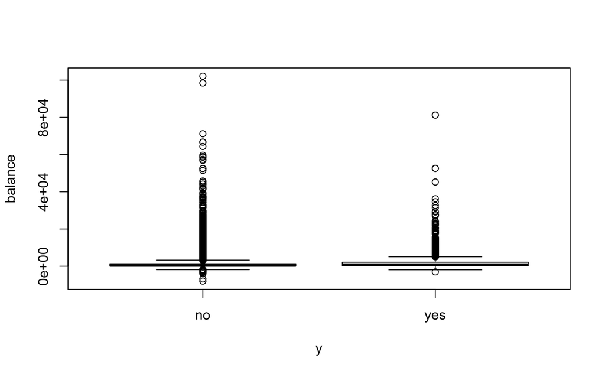

```r
# age, balance, day, duration, campaign, pdays, previous
boxplot(bank_copy$balance ~ bank_copy$y, xlab = "y", ylab = "balance")
```

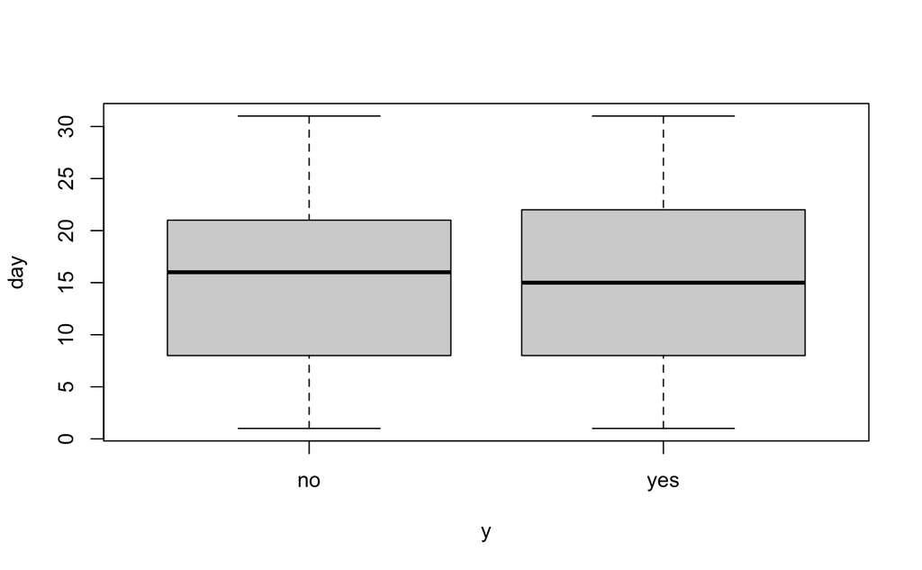

```r
boxplot(bank_copy$day ~ bank_copy$y, xlab = "y", ylab = "day")
```

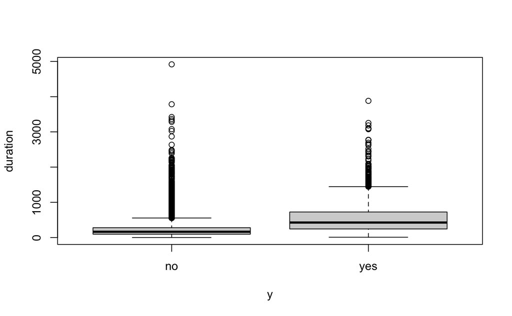

```r
boxplot(bank_copy$duration ~ bank_copy$y, xlab = "y", ylab = "duration")
```

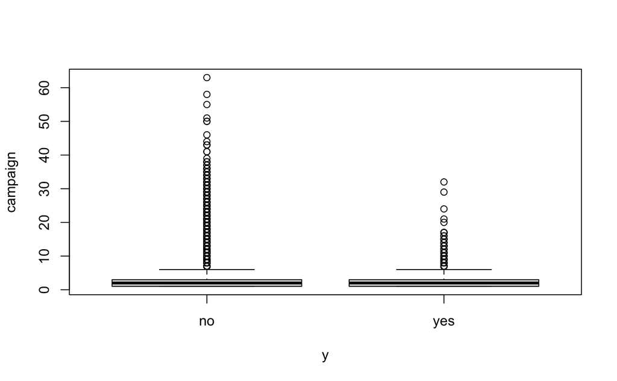

```r
boxplot(bank_copy$campaign ~ bank_copy$y, xlab = "y", ylab = "campaign")
```

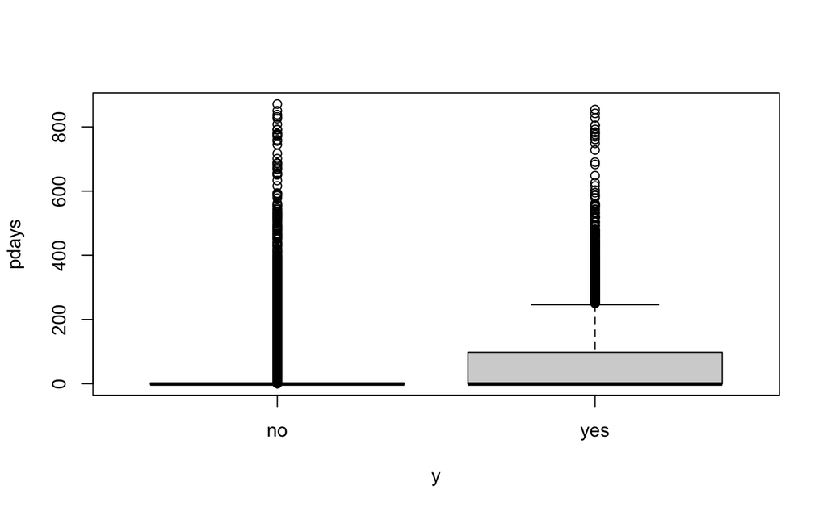

```r
boxplot(bank_copy$pdays ~ bank_copy$y, xlab = "y", ylab = "pdays")
```

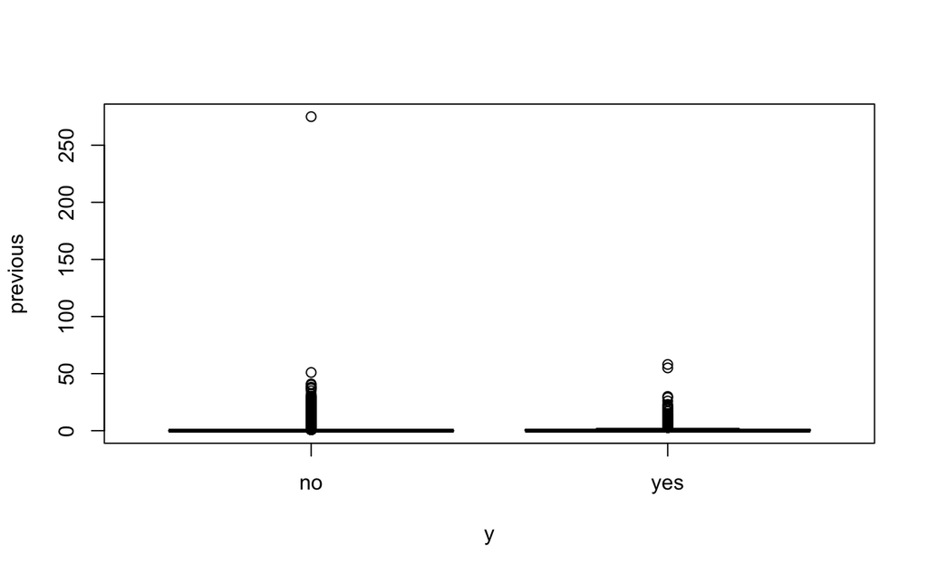

```r
boxplot(bank_copy$previous ~ bank_copy$y, xlab = "y", ylab = "previous")
```

According to this, all the variables have values less than the threshold value, therefore all are associated.

5. (1pt) Use the command colSums(is.na() to get the number of missing values in each column of your dataframe. Which columns have missing values? Note: some variables use “unknown” for missing values. Convert all “unknown” values to NA. You can do so by setting “na.strings” parameter to “unknown” when you read the file using read.csv.

```r
colSums(is.na(bank_copy))
```

```
      job   marital education   default   balance   housing      loan   contact       day     month  duration  campaign     pdays  previous
      288         0      1857         0         0         0         0     13020         0         0         0         0         0         0
 poutcome         y
    36959         0
```

The columns having missing values are: Job, Education, contact, poutcome.

6. (3 pt) There are several ways we can deal with missing values. The easiest approach is to remove all the rows with missing values. However, if a large number of rows have missing values removing them will result in loss of information and may affect the classifier performance. If a large number of rows have missing values, then it is typically better to substitute missing values. This is called data imputation. Several methods for missing data imputation exist. The most naïve method (which we will use here) is to replace the missing values with mean of the column (for a numerical column) or mode/majority value of the column (for a categorical column). We will use a more advanced data imputation method in a later module. For now, replace the missing values in a numerical column with the mean of the column and the missing values in a categorical column with the mode/majority of the column. After imputation, use colSums(is.na() to make sure that your dataframe no longer has missing values

So, According to this: It’s better to remove job and education missing values rows because as compared to the total rows ie. 45211 observations, these entries are very less. # We are using complete.cases function to remove the specific columns’ rows, then confirming by running the colSums method if the rows are removed.

```r
remove_cols <- c("job", "education")
bank_copy <- bank_copy[complete.cases(bank_copy[, remove_cols]), ]
colSums(is.na(bank_copy))
```

```
      job   marital education   default   balance   housing      loan   contact       day     month  duration  campaign     pdays  previous
        0         0         0         0         0         0         0     12286         0         0         0         0         0         0
 poutcome         y
    35286         0
```

# Now, for the contact and poutcome we’ll replace the missing values with the mode of the values as they both are categorical

```r
# Calculating the mode of the contact column by using table function:
table(bank_copy$contact)
```

```
 cellular telephone
    28213      2694
```

Here, “cellular” is the mode value, Therefore we’ll replace the missing values with Cellular. To do this, we need to use the dplyr package

```r
# install.packages("tidyverse")
library(tidyverse)
```

```r
# Using the mutate() function from the package and replacing it with cellular value, we can see that there are no missing values in contact
bank_copy <- bank_copy %>%
  mutate(contact = if_else(is.na(contact), "cellular", contact))
colSums(is.na(bank_copy))
```

```
      job   marital education   default   balance   housing      loan   contact       day     month  duration  campaign     pdays  previous
        0         0         0         0         0         0         0         0         0         0         0         0         0         0
 poutcome         y
    35286         0
```

```r
table(bank_copy$contact)
```

```
 cellular telephone
    40499      2694
```

# Performing the same with poutcome variable

```r
table(bank_copy$poutcome)
```

```
failure   other success
   4709    1774    1424
```

# According to this data, failure is our mode value and we’ll use this to replace with the missing values

```r
bank_copy <- bank_copy %>%
  mutate(poutcome = if_else(is.na(poutcome), "failure", poutcome))
colSums(is.na(bank_copy))
```

```
      job   marital education   default   balance   housing      loan   contact       day     month  duration  campaign     pdays  previous
        0         0         0         0         0         0         0         0         0         0         0         0         0         0
 poutcome         y
        0         0
```

```r
table(bank_copy$poutcome)
```

```
failure   other success
  39995    1774    1424
```

7. Set the seed of the random number generator to a fixed integer, say 1, so that I can reproduce your work: > set.seed(1)

```r
set.seed(1)
```

8. (1pt) Randomize the order of the rows in the dataset

```r
# To randomize the order of the rows
bank_copy <- bank_copy[sample(nrow(bank_copy), replace = FALSE),]
```

9. (2 pt) This dataset has several categorical variables. With the exception of few models ( such as Naiive Bayes and tree-based models) most machine learning models require numeric features and cannot work directly with categorical data. One way to deal with categorical variables is to assign numeric indices to each level. However, this imposes an artificial ordering on an unordered categorical variable. For example, suppose that we have a categorical variable primary color with three levels: “red”,”blue”,”green”. If we convert “red” to 0 , “blue” to 1 and “green” to 2 then we are telling our model that red < blue< green which is not correct. A better way to encode an unordered categorical variable is to do one-hot-encoding. In one hot-encoding we create a dummy binary variable for each level of a categorical variable. For example we can represent the primary color variable by three binary dummy variables, one for each color (red, blue, and green) . If the color is red, then the variable red takes value 1 while blue and green both take the value zero. Do one-hot-encoding of all your unordered categorical variables (except the target variable y). You can use the function one_hot from mltools package to one-hot encode all categorical variables in a dataset. Please refer to https://rdrr.io/cran/mltools/man/one_hot.html . Use option DropUnusedLevels=True to avoid creating a binary variable for unused levels of a factor variable. Please note that the one_hot function takes a data table not a dataframe. You can convert a dataframe to datatable by using as.data.table method https://www.rdocumentation.org/packages/data.table/versions/1.12.8/topics/as.data.table. Make sure to use library(data.table) before using as.data.table method. You can covert a datatable back to a dataframe by using as.data.frame method https://www.rdocumentation.org/packages/base/versions/3.6.2/topics/as.data.frame

```r
# For this, our unordered categorical variables are: job, marital, default, housing, loan, contact, month, poutcome
#install.packages('data.table')
#install.packages('mltools')
library('mltools')
library('data.table')
```

```r
# Converting the variables to factors
cols_to_convert <- c("job", "marital","education", "default", "housing", "loan", "contact", "month", "poutcome")
bank_copy <- bank_copy %>% mutate(across(all_of(cols_to_convert), factor))
```

```r
# Performing hot-encoding
bank_copy$job <- as.factor(bank_copy$job)
bank_copy$marital <- as.factor(bank_copy$marital)
bank_copy$education <- as.factor(bank_copy$education)
bank_copy$housing <- as.factor(bank_copy$housing)
bank_copy$default <- as.factor(bank_copy$default)
bank_copy$loan <- as.factor(bank_copy$loan)
bank_copy$contact <- as.factor(bank_copy$contact)
bank_copy$month <- as.factor(bank_copy$month)
bank_copy$poutcome <- as.factor(bank_copy$poutcome)
dt = as.data.table(bank_copy)
encoded_bank <- one_hot(dt, cols = "auto" , sparsifyNAs = FALSE , naCols = FALSE, dropCols = TRUE ,  dropUnusedLevels = TRUE)
bank_copy <- as.data.frame(encoded_bank)
```

```r
bank_copy
```

| job_admin. | job_blue-collar | job_entrepreneur | job_housemaid | job_management | job_retired | job_self-employed | job_services | job_student | job_technician | job_unemployed | marital_divorced | marital_married | marital_single | education_primary | education_secondary | education_tertiary | default_no | default_yes | balance | housing_no | housing_yes | loan_no | loan_yes | contact_cellular | contact_telephone | day | month_apr | month_aug | month_dec | … |
| --- | --- | --- | --- | --- | --- | --- | --- | --- | --- | --- | --- | --- | --- | --- | --- | --- | --- | --- | --- | --- | --- | --- | --- | --- | --- | --- | --- | --- | --- | --- |
| 0 | 0 | 0 | 0 | 1 | 0 | 0 | 0 | 0 | 0 | 0 | 0 | 1 | 0 | 0 | 0 | 1 | 1 | 0 | 12409 | 0 | 1 | 1 | 0 | 1 | 0 | 19 | 0 | 0 | 0 | … |
| 0 | 0 | 0 | 0 | 0 | 0 | 0 | 0 | 0 | 1 | 0 | 0 | 1 | 0 | 0 | 1 | 0 | 1 | 0 | 1633 | 0 | 1 | 1 | 0 | 1 | 0 | 19 | 0 | 0 | 0 | … |
| 0 | 1 | 0 | 0 | 0 | 0 | 0 | 0 | 0 | 0 | 0 | 0 | 0 | 1 | 1 | 0 | 0 | 1 | 0 | 52 | 0 | 1 | 1 | 0 | 1 | 0 | 24 | 0 | 0 | 0 | … |
| 0 | 1 | 0 | 0 | 0 | 0 | 0 | 0 | 0 | 0 | 0 | 0 | 0 | 1 | 0 | 1 | 0 | 1 | 0 | 79 | 1 | 0 | 0 | 1 | 1 | 0 | 20 | 0 | 0 | 0 | … |
| 0 | 0 | 1 | 0 | 0 | 0 | 0 | 0 | 0 | 0 | 0 | 0 | 1 | 0 | 0 | 1 | 0 | 1 | 0 | 30 | 1 | 0 | 1 | 0 | 1 | 0 | 30 | 1 | 0 | 0 | … |
| 1 | 0 | 0 | 0 | 0 | 0 | 0 | 0 | 0 | 0 | 0 | 0 | 1 | 0 | 0 | 1 | 0 | 1 | 0 | 1388 | 0 | 1 | 1 | 0 | 1 | 0 | 15 | 0 | 0 | 0 | … |
| 0 | 0 | 0 | 0 | 0 | 0 | 0 | 1 | 0 | 0 | 0 | 0 | 1 | 0 | 1 | 0 | 0 | 1 | 0 | 711 | 0 | 1 | 1 | 0 | 1 | 0 | 3 | 0 | 0 | 0 | … |
| 0 | 0 | 0 | 0 | 1 | 0 | 0 | 0 | 0 | 0 | 0 | 0 | 1 | 0 | 0 | 1 | 0 | 0 | 1 | 421 | 1 | 0 | 1 | 0 | 1 | 0 | 20 | 0 | 0 | 0 | … |
| 0 | 0 | 1 | 0 | 0 | 0 | 0 | 0 | 0 | 0 | 0 | 0 | 1 | 0 | 0 | 1 | 0 | 1 | 0 | 3119 | 0 | 1 | 1 | 0 | 1 | 0 | 20 | 0 | 0 | 0 | … |
| 0 | 0 | 0 | 0 | 1 | 0 | 0 | 0 | 0 | 0 | 0 | 0 | 0 | 1 | 0 | 0 | 1 | 1 | 0 | 0 | 1 | 0 | 1 | 0 | 1 | 0 | 27 | 0 | 1 | 0 | … |

[output cut: 990 more lines]

10. Split the data into training and test sets. Use the first 36168 rows for training and the rest for testing.

```r
# Splitting the data and using the random version of data so that we do not get biased training and testing split:
train_indices <- 1:36168
test_indices <- 36169:43193

# Split the data
training_set <- bank_copy[train_indices, -ncol(bank_copy)]
testing_set <- bank_copy[test_indices, -ncol(bank_copy)]
bank_copy$y <- as.factor(bank_copy$y)
training_set_labels <- bank_copy[train_indices,"y" ]
testing_set_labels <- bank_copy[test_indices, "y"]
```

11. (3 pts) Use 5-fold cross validation with KNN on the training set to predict the “y” variable and report the cross-validation accuracy. (Please use crossValidationError function in slides 51-53 of module 4 lecture notes and modify it to compute accuracy instead of error. The accuracy is simply 1- error)

```r
# First of all, we'll use
# install.packages("caret")
library(caret)
#install.packages("class")
library(class)
library(lattice)
```

```r
#folds=createFolds(training_set_labels,k=5)
#str(folds)
normalize=function(train,val) {
  #get the statistics (min and max) from the train data
  train_col_mins= sapply(train, min)
  train_col_maxs= sapply(train,max)
  #define a function to do min-max normalization
  min_max_normalize=function(x, min, max) {return ((x-min)/(max-min))}
  # apply min-max_normalize to both train and validation sets using the #
  train_n=as.data.frame(mapply(min_max_normalize, train, train_col_mins, train_col_maxs ))
  val_n=as.data.frame(mapply(min_max_normalize, val, train_col_mins,train_col_maxs ))
  # return the normalized train and validation sets
  return (list("train_n"=train_n, "val_n"=val_n))
}

knn_fold=function(features,labels,fold,kneighbors){
  train=features[-fold,]
  val=features[fold,]
  data_n= normalize(train, val)
  train_n= data_n$train_n
  val_n= data_n$val_n
  train_labels=labels[-fold]
  validation_labels=labels[fold]
  val_preds=knn(train_n,val_n,train_labels,k=kneighbors)
  t= table(validation_labels,val_preds)
  error=(t[1,2]+t[2,1])/sum(t)
  return(error)
}
crossValidationError=function(features,labels,kneighbors){
  folds=createFolds(labels,k=5)
  errors=sapply(folds,knn_fold,features=features,
  labels=labels,kneighbors=kneighbors)
  return(mean(errors))}


errors = crossValidationError(training_set,training_set_labels,kneighbors=5)
errors
```

```
[1] 0.1073878
```

```r
accuracy <- 1-errors
accuracy
```

```
[1] 0.8926122
```

12. (2 pts) Tune K (the number of nearest neighbors) by trying out different values (starting from k=1 to k=sqrt(n) where n is the number of observations in the training set (for example k=1,5,10,20 50,100, sqrt(n) ). Draw a plot of cross validation accuracy for different values of K. Which value of K seems to perform the best on this data set? (Note: the higher the cross validation accuracy ( or the lower the cross validation error) the better is the model. You can find an example in slides 54-55 of module 4 lecture notes) Note: This might take several minutes to run on your machine, be patient.

```r
# n = 36,168 ; sqrt(36168) is approx 190
k_values <- c(1, 5, 10, 20, 50, 100, round(sqrt(36168)))
errors <- sapply(k_values,crossValidationError,features=training_set,labels=training_set_labels)
errors
```

```
[1] 0.1307232 0.1086319 0.1068348 0.1067241 0.1082726 0.1108715 0.1129175
```

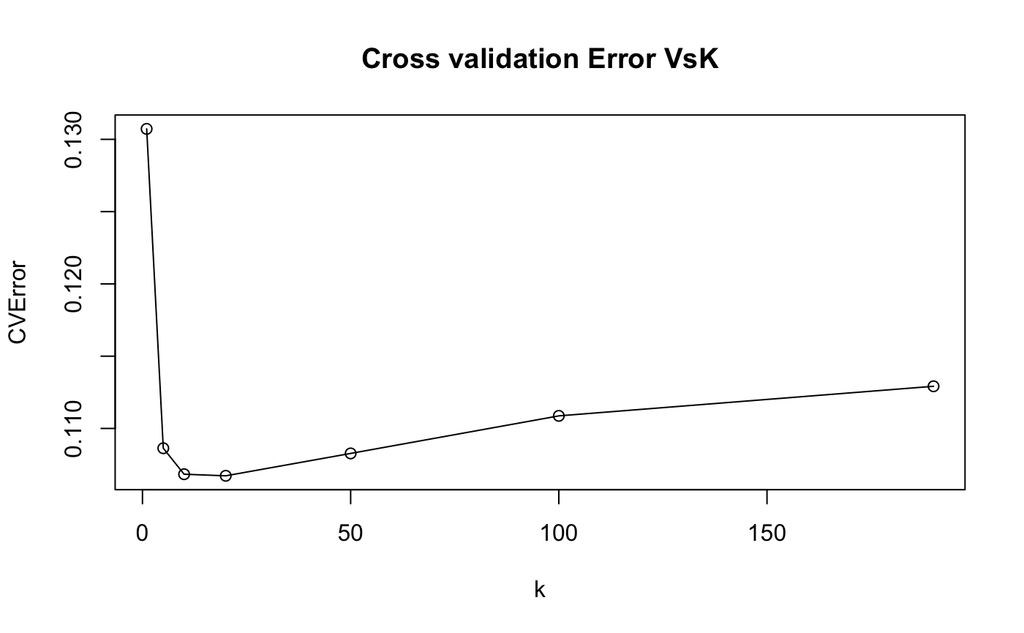

```r
# Plotting

plot(errors ~ k_values, main="Cross validation Error VsK", xlab="k", ylab="CVError")
lines(errors ~ k_values)
```

13. (3 pt) Use “knn” function to train a knn model on the training set using the best value of K you found above and get the predicted values for the target variable y in the test set.

```r
test_preds <- knn(training_set,testing_set,training_set_labels,k=20)
t <- table(test_preds, testing_set_labels)
t
```

```
          testing_set_labels
test_preds   no  yes
       no  6067  637
       yes  142  179
```

```r
bank_predicted_values <- as.factor(test_preds)
```

14. (2pt) Compare the predicted target (y) with the true target (y) in the test set using a cross table.

```r
testing_set_labels <- as.factor(testing_set_labels)
confusion_matrix <- confusionMatrix(bank_predicted_values, testing_set_labels)
print(confusion_matrix)
```

```
Confusion Matrix and Statistics

          Reference
Prediction   no  yes
       no  6067  637
       yes  142  179

               Accuracy : 0.8891
                 95% CI : (0.8815, 0.8964)
    No Information Rate : 0.8838
    P-Value [Acc > NIR] : 0.0864

                  Kappa : 0.2668

 Mcnemar's Test P-Value : <2e-16

            Sensitivity : 0.9771
            Specificity : 0.2194
         Pos Pred Value : 0.9050
         Neg Pred Value : 0.5576
             Prevalence : 0.8838
         Detection Rate : 0.8636
   Detection Prevalence : 0.9543
      Balanced Accuracy : 0.5982

       'Positive' Class : no
```